# Final Project Presentation

## Introduction

- For my final project I created extended Week 2 Assignment with the knowledge that we have gain throughout the semester.
- I will be showing the ratings of all the movies Michael Bay has directed and their ratings from multiple sources and normalizing the ratings to create one final rating for the end user.

## OMDB API

- Open Source API - Just need to sign up and get a limited amount of calls to the API a day
- Provides a lot of information on the movie including the scores from IMDB, Rotten Tomato, and Metacritics
- Example of a API Call

```
##            Length Class      Mode
## Title      1      -none-     character
## Year       1      -none-     character
## Rated      1      -none-     character
## Released   1      -none-     character
## Runtime    1      -none-     character
## Genre      1      -none-     character
## Director   1      -none-     character
## Writer     1      -none-     character
## Actors     1      -none-     character
## Plot       1      -none-     character
## Language   1      -none-     character
## Country    1      -none-     character
## Awards     1      -none-     character
## Poster     1      -none-     character
## Ratings    2      data.frame list
## Metascore  1      -none-     character
## imdbRating 1      -none-     character
## imdbVotes  1      -none-     character
## imdbID     1      -none-     character
## Type       1      -none-     character
## DVD        1      -none-     character
## BoxOffice  1      -none-     character
## Production 1      -none-     character
## Website    1      -none-     character
## Response   1      -none-     character
```

## RobertEbert.com

- Another rating website without a RESTFUL API
- Had a rated list of movies that Michael Bay directed
- The Rating system rated movies out of 4
- Manually entered the information into a Excel Spreadsheet and imported it into the data set

[figure not shown]

## Ratings

```
##                    Source  Value
## 1 Internet Movie Database 6.9/10
## 2         Rotten Tomatoes    42%
## 3              Metacritic 41/100
```

## Min Max Normalization

- Simple to implement compared to using Z Score
- Do not have the population mean and standard deviation to use the Z Score
- Allows for bounded range
- Returns a value from 0 to 1

\[ X' = \frac{(X - X_{min})}{X_{max} - X_{min}} \]

## Results

Here is the original ratings before the ratings were normalized

| Movie | Internet Movie Database | Rotten Tomatoes | Metacritic | Robertebert.com |
| --- | --- | --- | --- | --- |
| Bad Boys | 6.9/10 | 42% | 41/100 | NA |
| The Rock | 7.4/10 | 66% | 58/100 | 3.5/4.0 |
| Armageddon | 6.7/10 | 38% | 42/100 | 1.0/4.0 |
| Pearl Harbor | 6.2/10 | 24% | 44/100 | 1.5/4.0 |
| Bad Boys II | 6.6/10 | 23% | 38/100 | 1.0/4.0 |
| The Island | 6.8/10 | 40% | 50/100 | 3.0/4.0 |

## Results

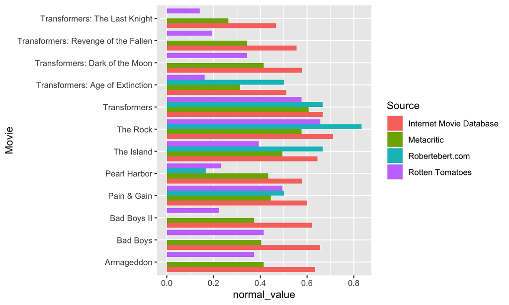

## Results

Here is the ratings with the normalized rates

| Movie | Internet Movie Database | Rotten Tomatoes | Metacritic | Robertebert.com |
| --- | --- | --- | --- | --- |
| Bad Boys | 0.6555556 | 0.4141414 | 0.4040404 | NA |
| The Rock | 0.7111111 | 0.6565657 | 0.5757576 | 0.8333333 |
| Armageddon | 0.6333333 | 0.3737374 | 0.4141414 | 0.0000000 |
| Pearl Harbor | 0.5777778 | 0.2323232 | 0.4343434 | 0.1666667 |
| Bad Boys II | 0.6222222 | 0.2222222 | 0.3737374 | 0.0000000 |
| The Island | 0.6444444 | 0.3939394 | 0.4949495 | 0.6666667 |

## Results

With all the rates normalized and averaged we can now see a simple graph which shows which are the best Michael Bay movie based on the different sources. We can see that The Rock is the most popular Micheal Bay movie

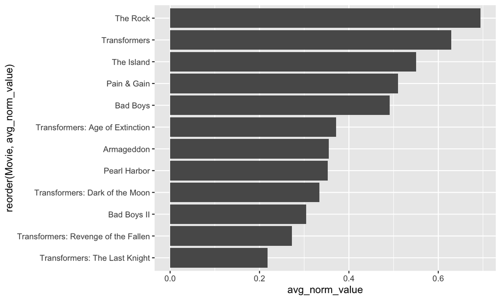

## Challenges

- Looking for a solution to normalize the scores into one score.
- Was trying very hard to use the Z Score method and see if i can get the popluation mean and standard deviation
- Shows that sometimes the easiest solutions are the better solution
- Using R Presentation instead of Powerpoint